# Life Expectancy (Regression Problem)

A reminder that before imputing the missing values we scaled HepatitisB.

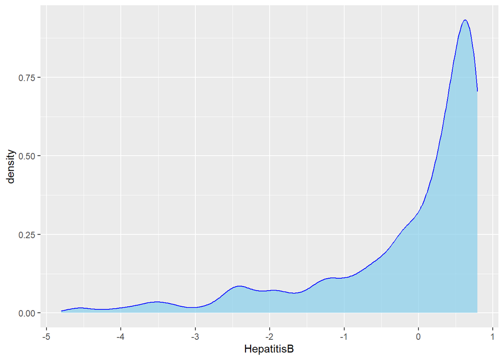

```r
ggplot(life_data, aes(x = HepatitisB)) +
  geom_density(fill = "skyblue", color = "blue", alpha = 0.7)
```

Mean_BMI

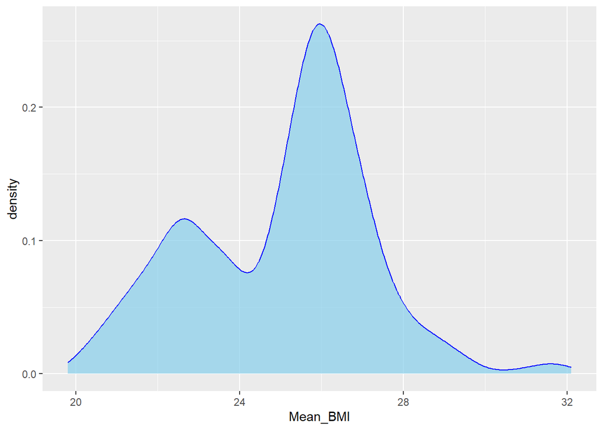

```r
ggplot(life_data, aes(x = Mean_BMI)) +
  geom_density(fill = "skyblue", color = "blue", alpha = 0.7)
```

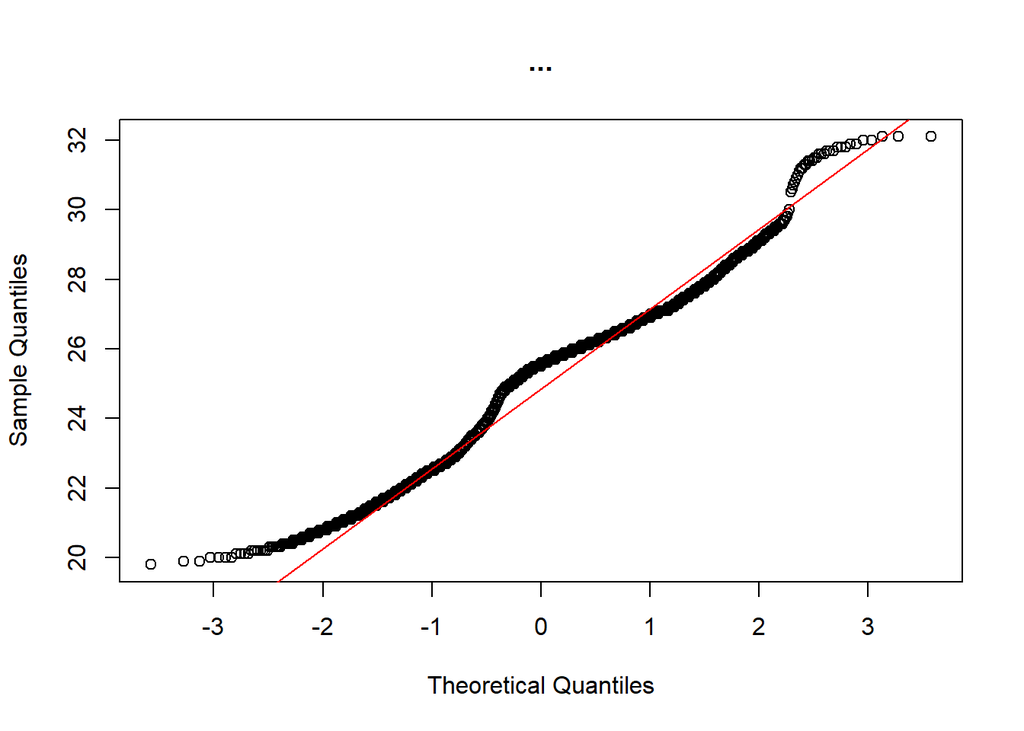

```r
# Check for Normality
qqnorm(life_data$Mean_BMI, main="...")
qqline(life_data$Mean_BMI, col = "red")
```

```r
lillie.test(life_data$Mean_BMI)
```

```
##
##  Lilliefors (Kolmogorov-Smirnov) normality test
##
## data:  life_data$Mean_BMI
## D = 0.11019, p-value < 2.2e-16
```

Population

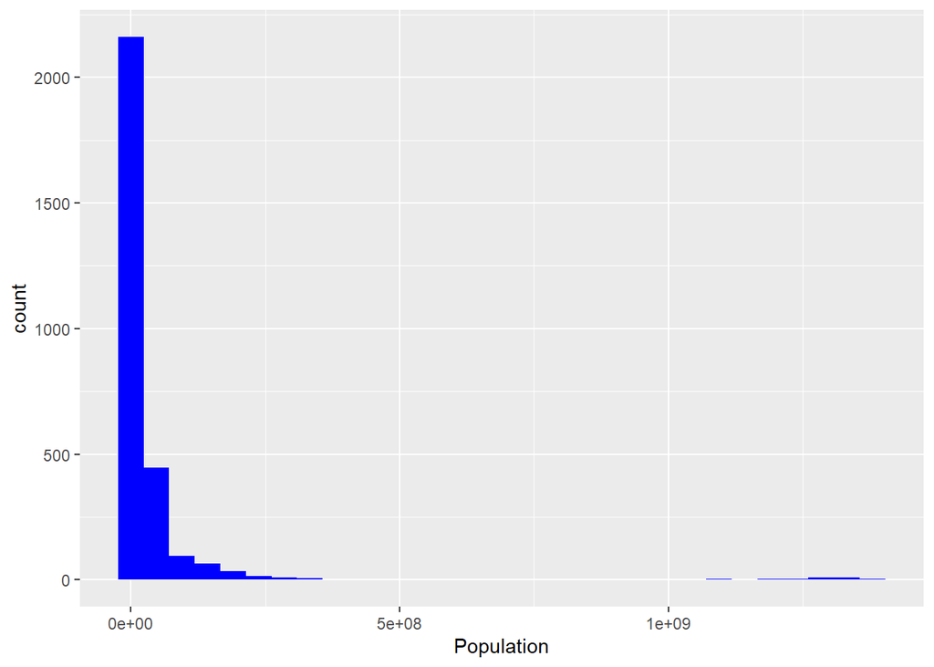

```r
# Histogram
ggplot(life_data, aes(x = Population)) + geom_histogram(fill = "blue")
```

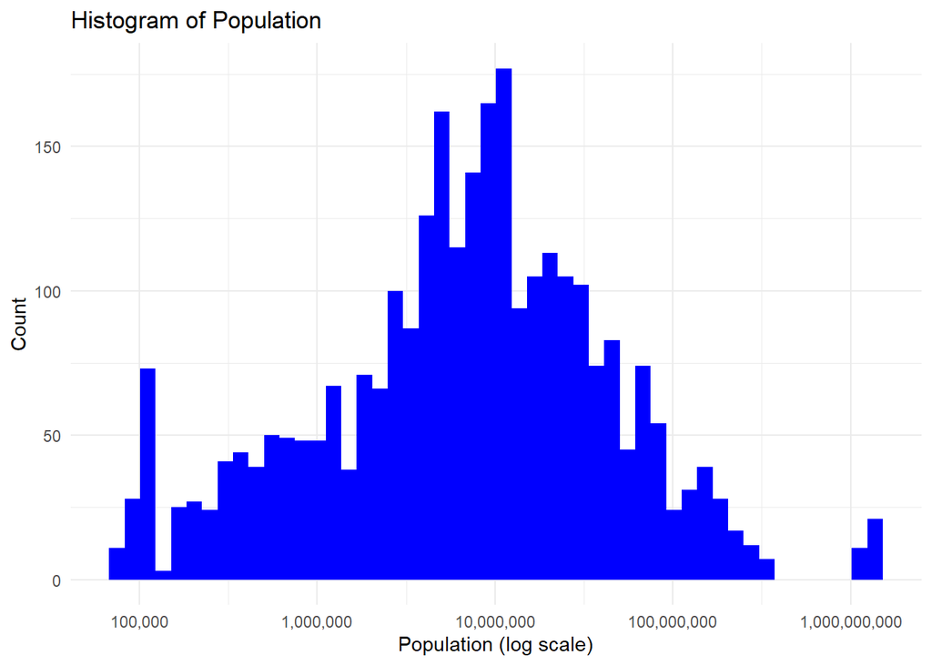

```r
ggplot(life_data, aes(x = Population)) +
  geom_histogram(fill = "blue", bins = 50) +
  scale_x_log10(labels = scales::comma) +
  labs(x="Population (log scale)", y = "Count", title = "Histogram of Population") +
  theme_minimal()
```

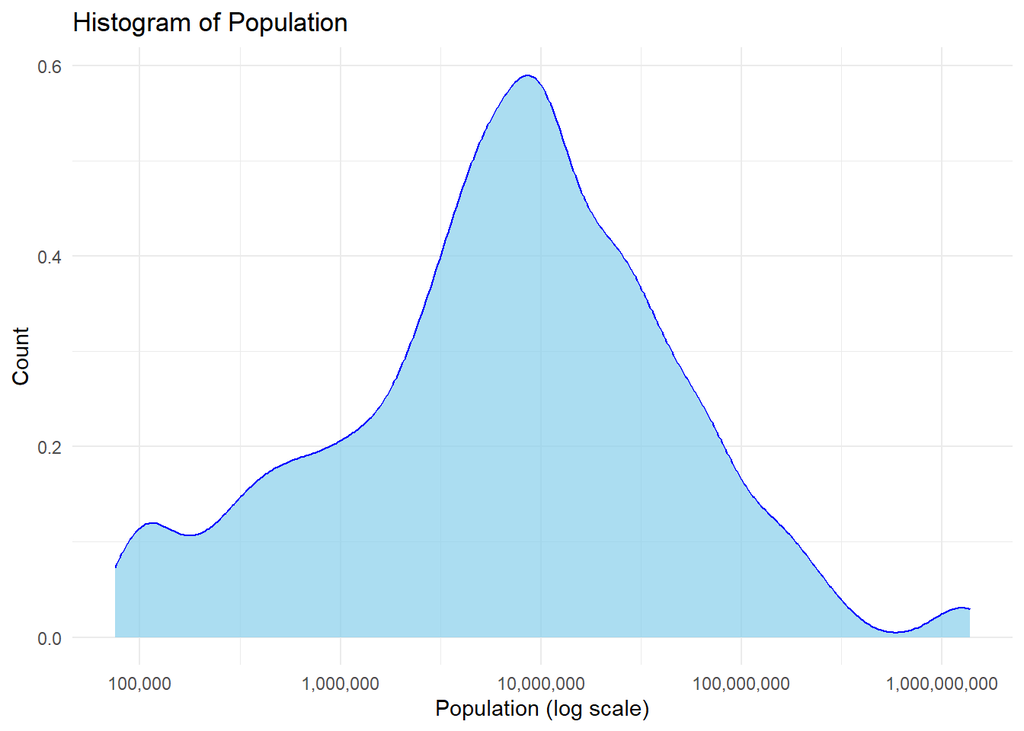

```r
ggplot(life_data, aes(x = Population)) +
  geom_density(fill = "skyblue", color = "blue", alpha = 0.7) +
  scale_x_log10(labels = scales::comma) +
  labs(x="Population (log scale)", y = "Count", title = "Histogram of Population") +
  theme_minimal()
```

```r
lillie.test(log(life_data$Population))
```

```
##
##  Lilliefors (Kolmogorov-Smirnov) normality test
##
## data:  log(life_data$Population)
## D = 0.053655, p-value < 2.2e-16
```

GDP per capita

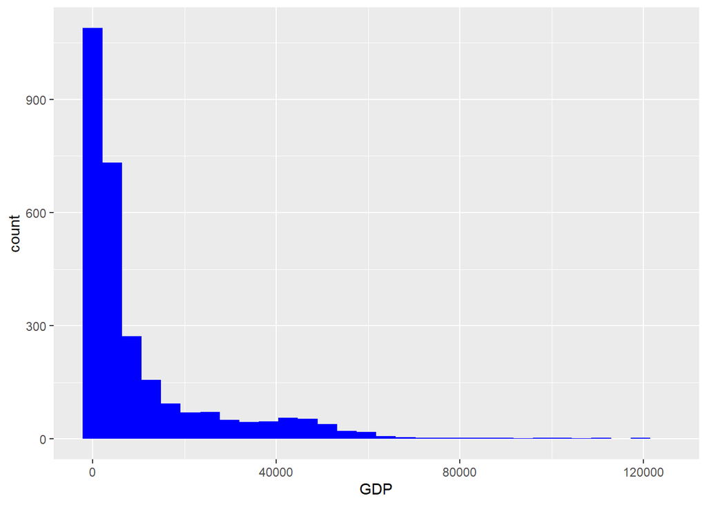

```r
# Histogram
ggplot(life_data, aes(x = GDP)) + geom_histogram(fill = "blue")
```

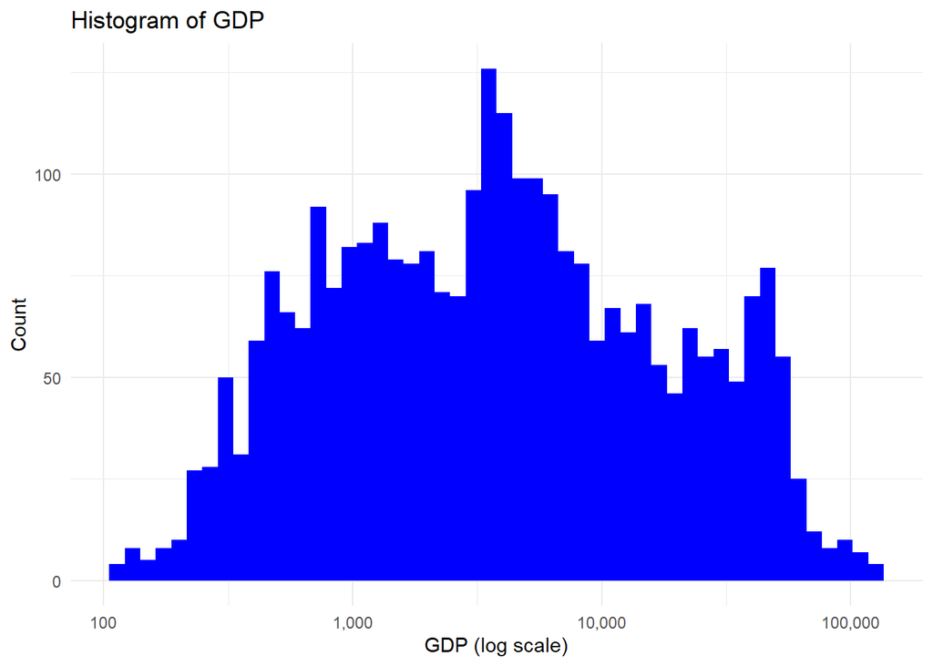

```r
ggplot(life_data, aes(x = GDP)) +
  geom_histogram(fill = "blue", bins = 50) +
  scale_x_log10(labels = scales::comma) +
  labs(x="GDP (log scale)", y = "Count", title = "Histogram of GDP") +
  theme_minimal()
```

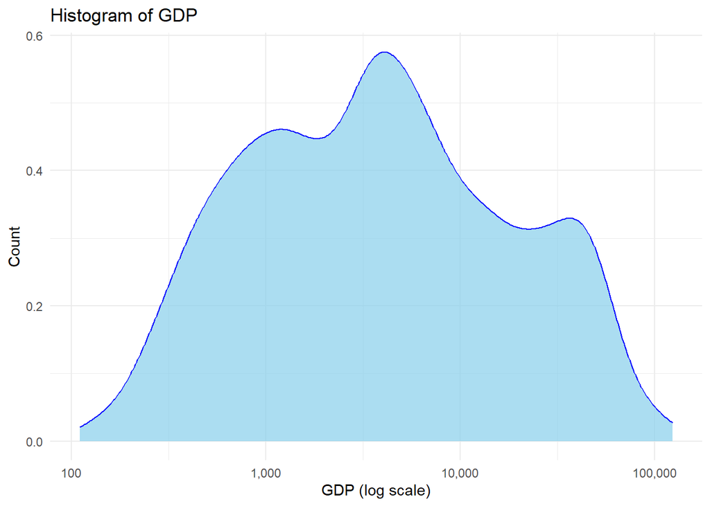

```r
ggplot(life_data, aes(x = GDP)) +
  geom_density(fill = "skyblue", color = "blue", alpha = 0.7) +
  scale_x_log10(labels = scales::comma) +
  labs(x="GDP (log scale)", y = "Count", title = "Histogram of GDP") +
  theme_minimal()
```

```r
lillie.test(log(life_data$GDP))
```

```
##
##  Lilliefors (Kolmogorov-Smirnov) normality test
##
## data:  log(life_data$GDP)
## D = 0.042456, p-value = 6.087e-13
```

So for Population and GDP per capita maybe later will be better to use log transformation for fitting our model.

Under five deaths

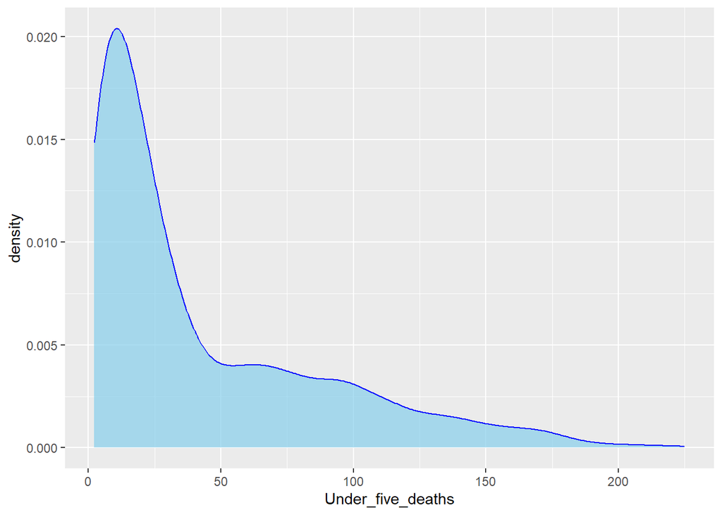

```r
ggplot(life_data, aes(x = Under_five_deaths)) +
  geom_density(fill = "skyblue", color = "blue", alpha = 0.7)
```

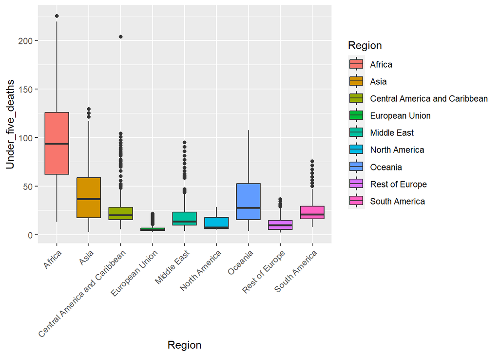

```r
ggplot(life_data, aes(x = Region, y = Under_five_deaths)) +
  geom_boxplot(aes(fill = Region)) +
  theme(axis.text.x = element_text(angle = 45, hjust = 1))
```

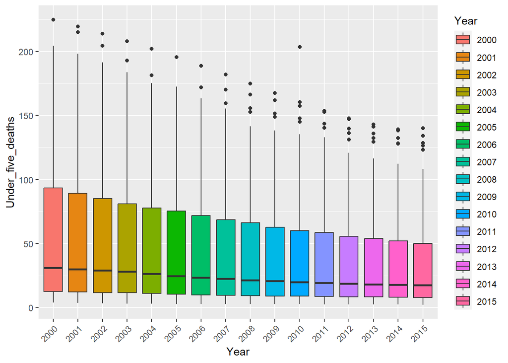

```r
ggplot(life_data, aes(x = Year, y = Under_five_deaths)) +
  geom_boxplot(aes(fill = Year)) +
  theme(axis.text.x = element_text(angle = 45, hjust = 1))
```

```r
max_index <- which.max(life_data$Under_five_deaths[life_data$Region == "Central America and Caribbean"])
life_data[life_data$Region == "Central America and Caribbean",][max_index, ]
```

```
##                            Region Country Year Infant_deaths Under_five_deaths
## 226 Central America and Caribbean   Haiti 2010         102.6             203.6
##     Thinness_ten_nineteen_years Thinness_five_nine_years Schooling
## 226                           4                        4       4.7
##     Incidents_HIV Economy_status_Developed Economy_status_Developing
## 226           0.9                        0                         1
##     Life_expectancy Population      GDP Economy_status Polio Measles
## 226            60.5    9842880 1204.862     Developing    66      64
##     Adult_mortality Alcohol Diphtheria  HepatitisB Mean_BMI
## 226             683    2.28         67 -0.07243922     24.6
```

There was an Earthquake in Haiti in 2010 and that’s why we have a big number of under five and infant deaths.

Infant deaths

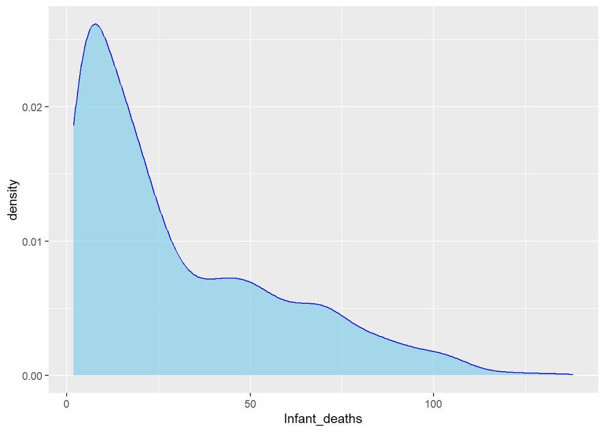

```r
ggplot(life_data, aes(x = Infant_deaths)) +
  geom_density(fill = "skyblue", color = "blue", alpha = 0.7)
```

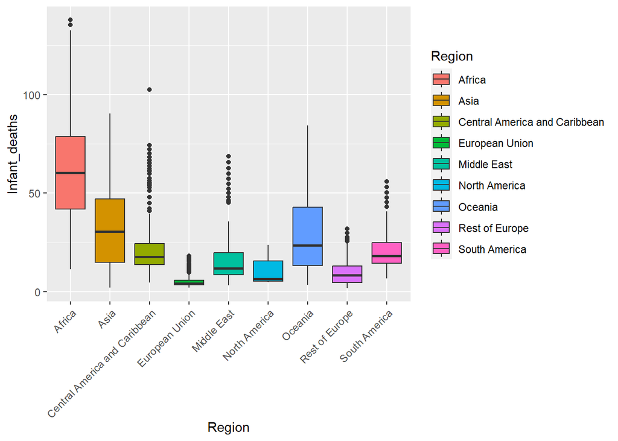

```r
ggplot(life_data, aes(x = Region, y = Infant_deaths)) +
  geom_boxplot(aes(fill = Region)) +
  theme(axis.text.x = element_text(angle = 45, hjust = 1))
```

Thinness 10-19 years and Thinness 5-9 years

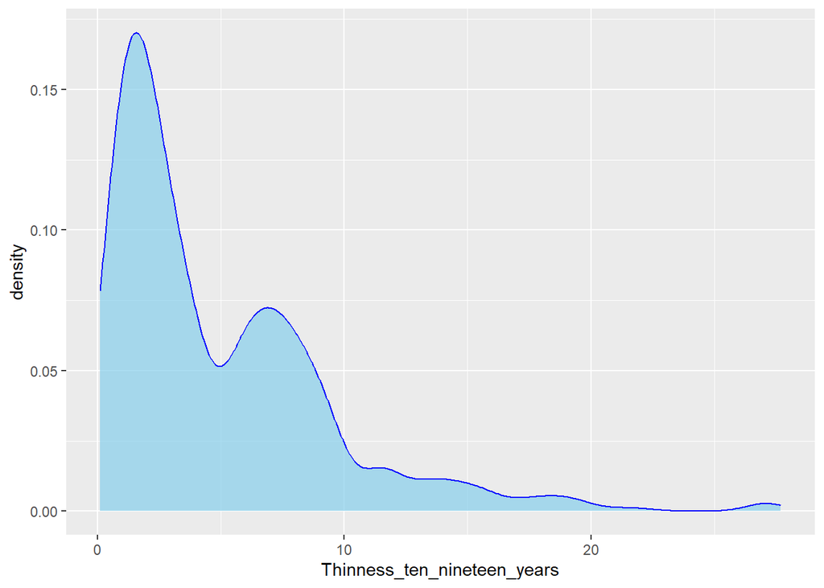

```r
ggplot(life_data, aes(x = Thinness_ten_nineteen_years)) +
  geom_density(fill = "skyblue", color = "blue", alpha = 0.7)
```

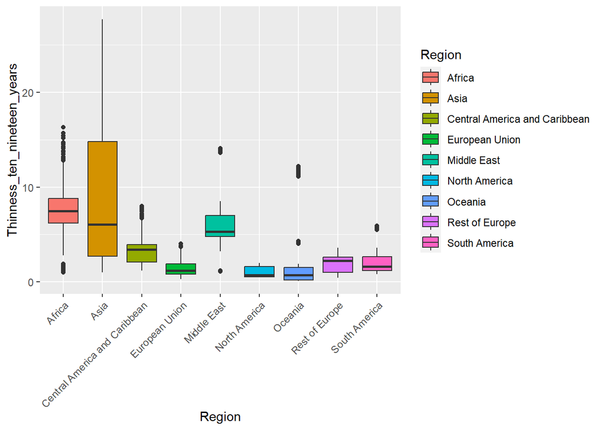

```r
# Boxplot
ggplot(life_data, aes(x = Region, y = Thinness_ten_nineteen_years)) +
  geom_boxplot(aes(fill = Region)) +
  theme(axis.text.x = element_text(angle = 45, hjust = 1))
```

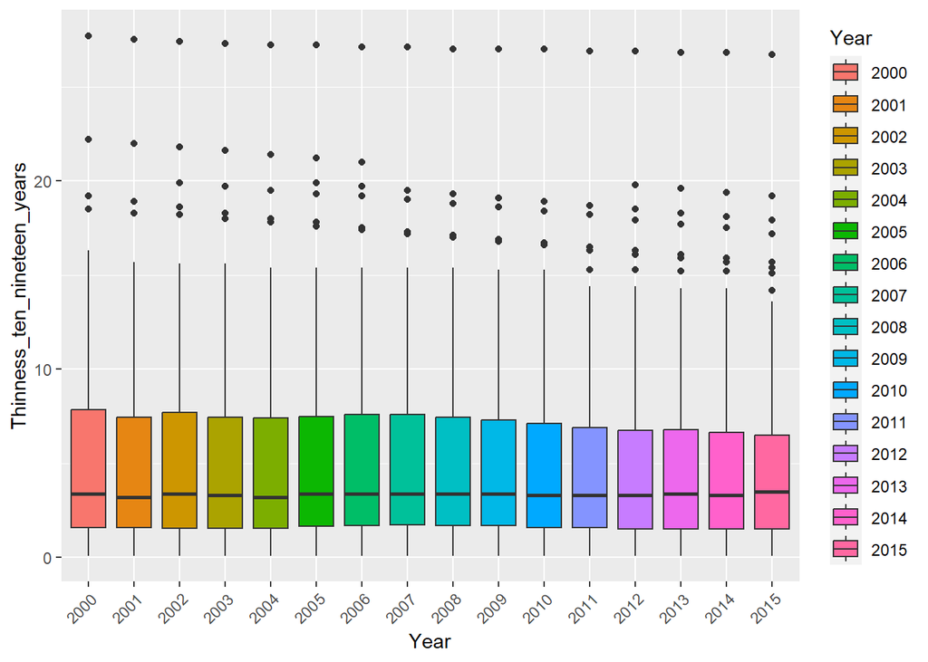

```r
ggplot(life_data, aes(x = Year, y = Thinness_ten_nineteen_years)) +
  geom_boxplot(aes(fill = Year)) +
  theme(axis.text.x = element_text(angle = 45, hjust = 1))
```

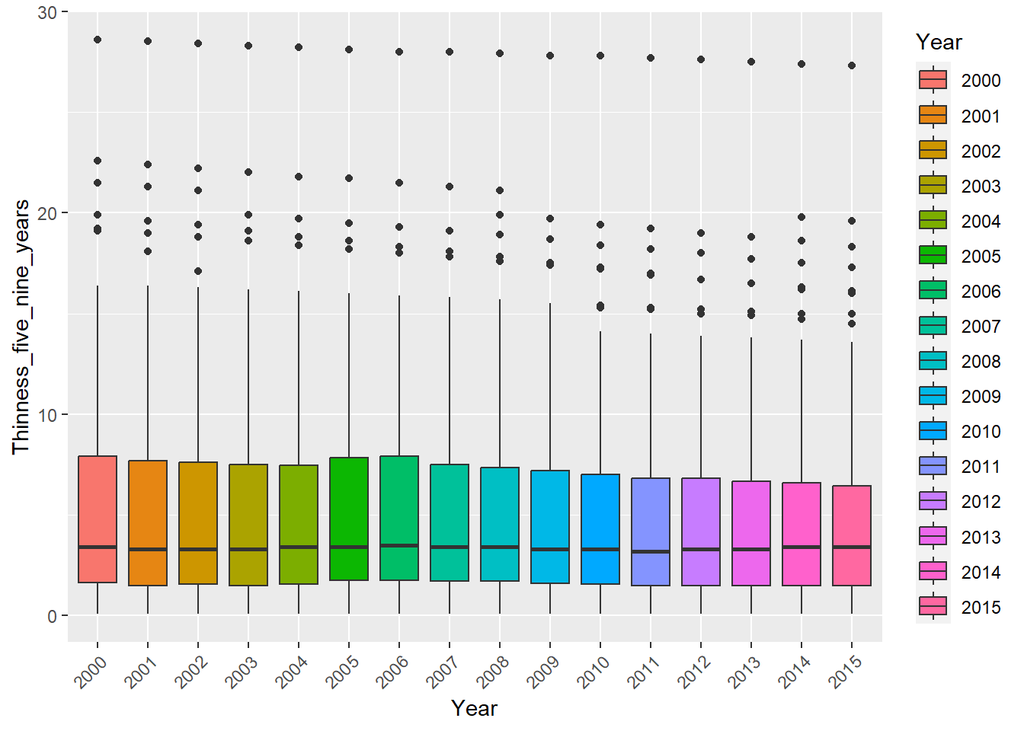

```r
ggplot(life_data, aes(x = Year, y = Thinness_five_nine_years)) +
  geom_boxplot(aes(fill = Year)) +
  theme(axis.text.x = element_text(angle = 45, hjust = 1))
```

```r
life_data %>% group_by(Year) %>% slice(which.max(Thinness_ten_nineteen_years))
```

```
## # A tibble: 16 × 22
## # Groups:   Year [16]
##    Region Country Year  Infant_deaths Under_five_deaths Thinness_ten_nineteen_…¹
##    <chr>  <chr>   <fct>         <dbl>             <dbl>                    <dbl>
##  1 Asia   India   2000           66.7              91.7                     27.7
##  2 Asia   India   2001           64.4              88.1                     27.5
##  3 Asia   India   2002           62.1              84.5                     27.4
##  4 Asia   India   2003           60                81.1                     27.3
##  5 Asia   India   2004           57.8              77.8                     27.2
##  6 Asia   India   2005           55.7              74.4                     27.2
##  7 Asia   India   2006           53.6              71.1                     27.1
##  8 Asia   India   2007           51.5              67.9                     27.1
##  9 Asia   India   2008           49.4              64.6                     27
## 10 Asia   India   2009           47.2              61.4                     27
## 11 Asia   India   2010           45.1              58.2                     27
## 12 Asia   India   2011           43                55                       26.9
## 13 Asia   India   2012           40.9              52                       26.9
## 14 Asia   India   2013           38.8              49                       26.8
## 15 Asia   India   2014           36.9              46.2                     26.8
## 16 Asia   India   2015           34.9              43.5                     26.7
## # ℹ abbreviated name: ¹Thinness_ten_nineteen_years
## # ℹ 16 more variables: Thinness_five_nine_years <dbl>, Schooling <dbl>,
## #   Incidents_HIV <dbl>, Economy_status_Developed <int>,
## #   Economy_status_Developing <int>, Life_expectancy <dbl>, Population <dbl>,
## #   GDP <dbl>, Economy_status <fct>, Polio <dbl>, Measles <dbl>,
## #   Adult_mortality <dbl>, Alcohol <dbl>, Diphtheria <dbl>, HepatitisB <dbl>,
## #   Mean_BMI <dbl>
```

We observe that the maximum `Thinness_ten_nineteen_years` for each year are all from India.

Schooling

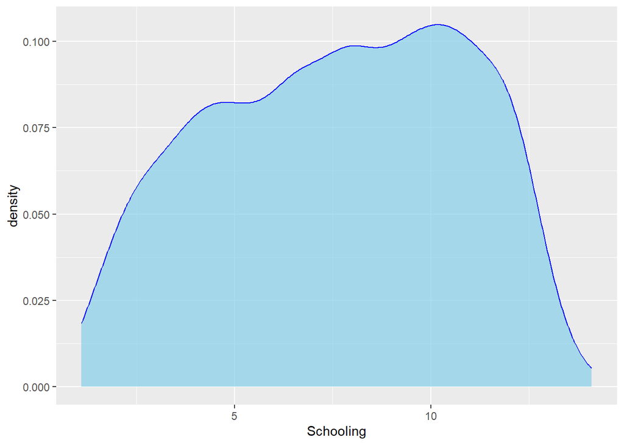

```r
ggplot(life_data, aes(x = Schooling)) +
  geom_density(fill = "skyblue", color = "blue", alpha = 0.7)
```

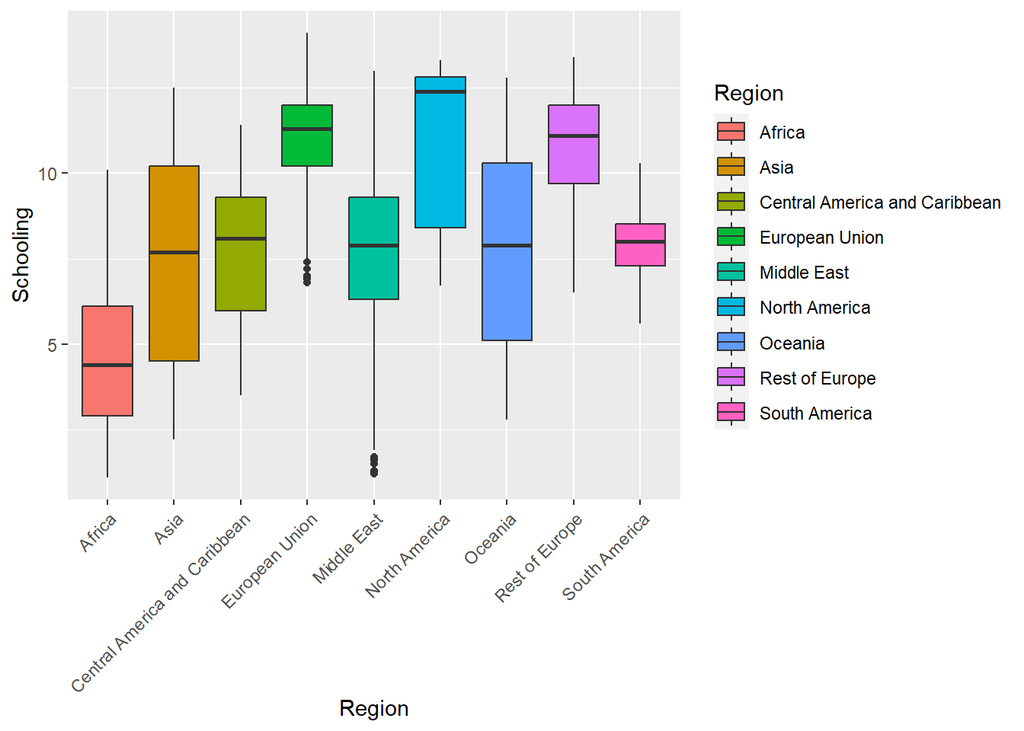

```r
# Boxplot
ggplot(life_data, aes(x = Region, y = Schooling)) +
  geom_boxplot(aes(fill = Region)) +
  theme(axis.text.x = element_text(angle = 45, hjust = 1))
```

We can see the differences of Schooling by Region.

Incidents of HIV

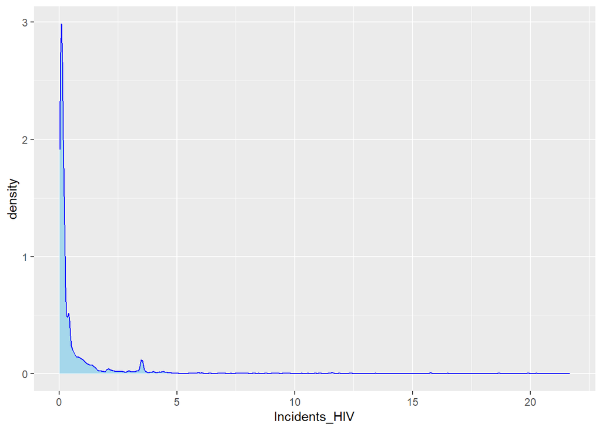

```r
ggplot(life_data, aes(x = Incidents_HIV)) +
  geom_density(fill = "skyblue", color = "blue", alpha = 0.7)
```

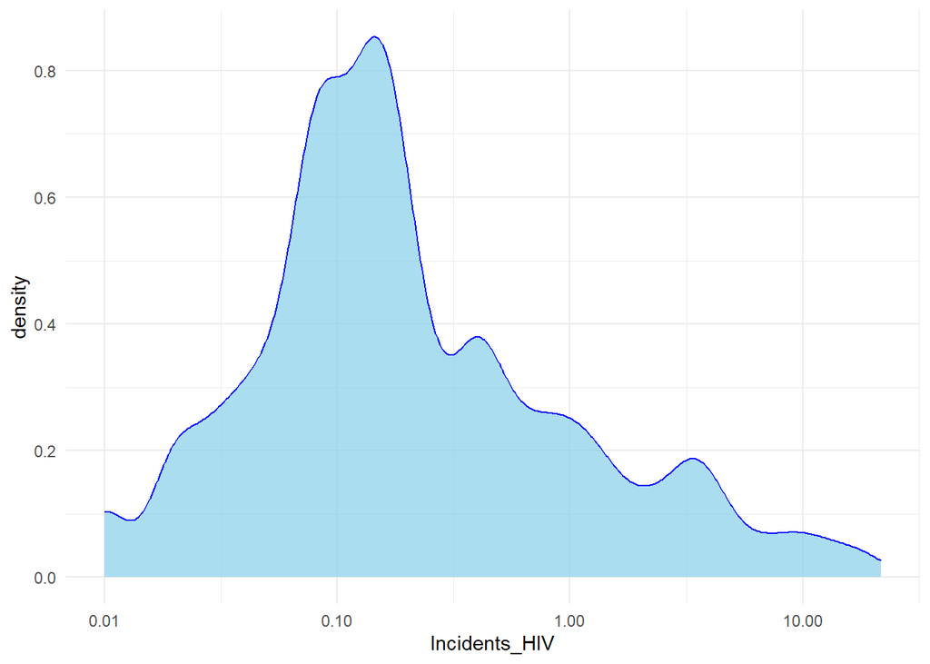

```r
ggplot(life_data, aes(x = Incidents_HIV)) +
  geom_density(fill = "skyblue", color = "blue", alpha = 0.7) +
  scale_x_log10(labels = scales::comma) + theme_minimal()
```

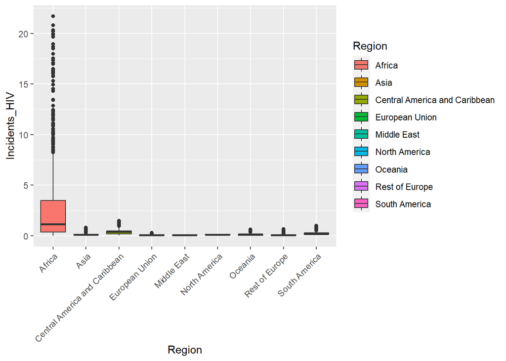

```r
ggplot(life_data, aes(x = Region, y = Incidents_HIV)) +
  geom_boxplot(aes(fill = Region)) +
  theme(axis.text.x = element_text(angle = 45, hjust = 1))
```

Incidents HIV maybe should be log transformed before fitting our model. Another observation here is that Africa has much higher number of incidents HIV compare to other Regions.

Polio and Measles

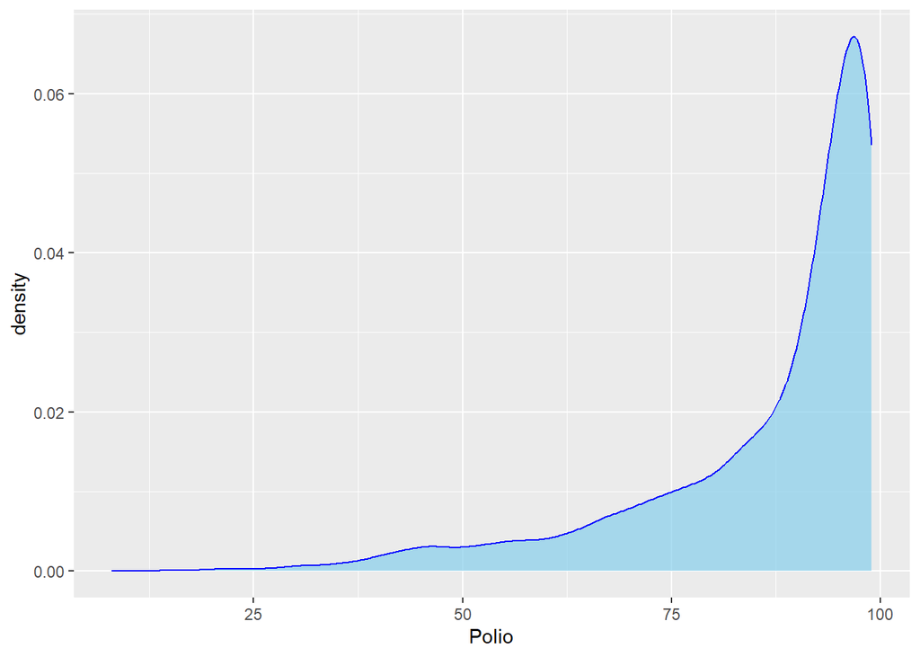

```r
ggplot(life_data, aes(x = Polio)) +
  geom_density(fill = "skyblue", color = "blue", alpha = 0.7)
```

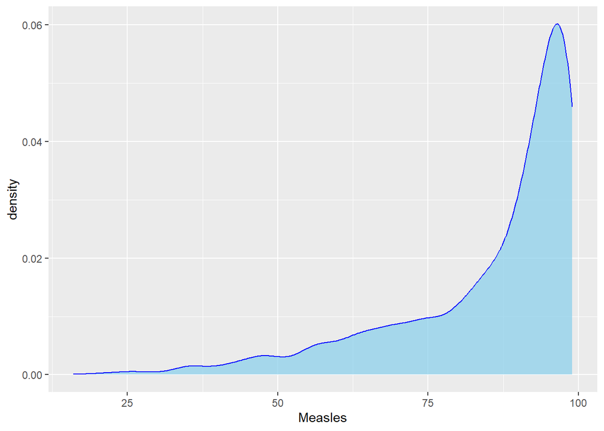

```r
ggplot(life_data, aes(x = Measles)) +
  geom_density(fill = "skyblue", color = "blue", alpha = 0.7)
```

Adult mortality

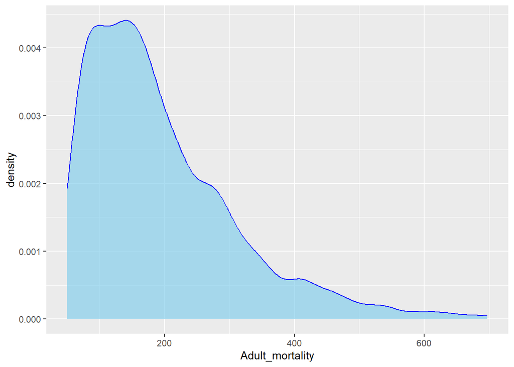

```r
ggplot(life_data, aes(x = Adult_mortality)) +
  geom_density(fill = "skyblue", color = "blue", alpha = 0.7)
```

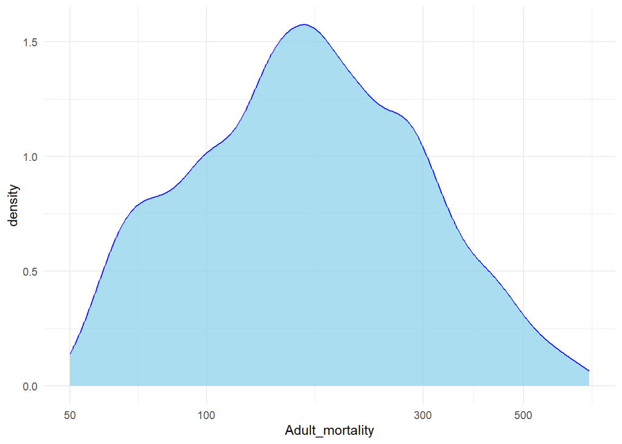

```r
ggplot(life_data, aes(x = Adult_mortality)) +
  geom_density(fill = "skyblue", color = "blue", alpha = 0.7) +
  scale_x_log10(labels = scales::comma) + theme_minimal()
```

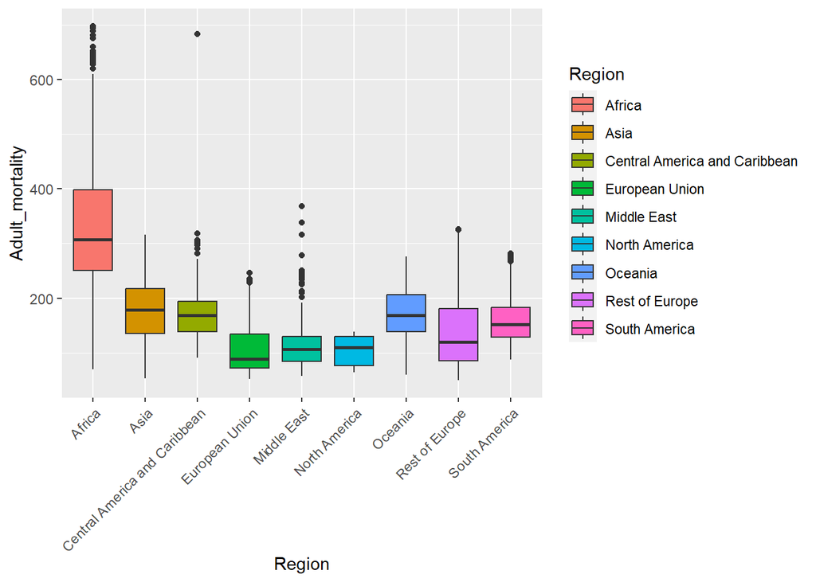

```r
# Boxplot
ggplot(life_data, aes(x = Region, y = Adult_mortality)) +
  geom_boxplot(aes(fill = Region)) +
  theme(axis.text.x = element_text(angle = 45, hjust = 1))
```

Adult mortality indicates the probability of dying between the ages of 15 and 60 per 1000 individuals. Africa region has the highest median again.

Correlations

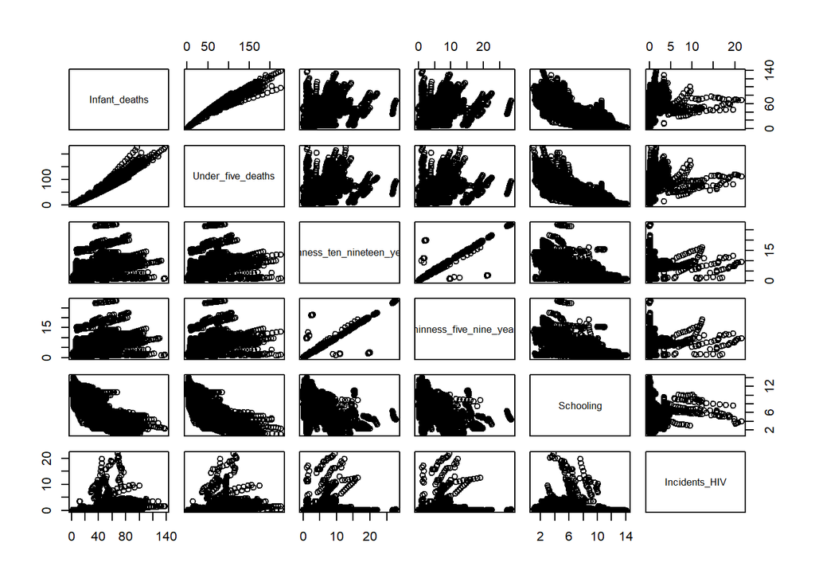

```r
# Get only the numeric data
numeric_cols <- sapply(life_data, is.numeric)
numeric_data <- life_data[numeric_cols]
# No need to have both developing and developed
numeric_data$Economy_status_Developing <- NULL
# Scatterplot matrix of data
pairs(numeric_data[,c(1:6)])
```

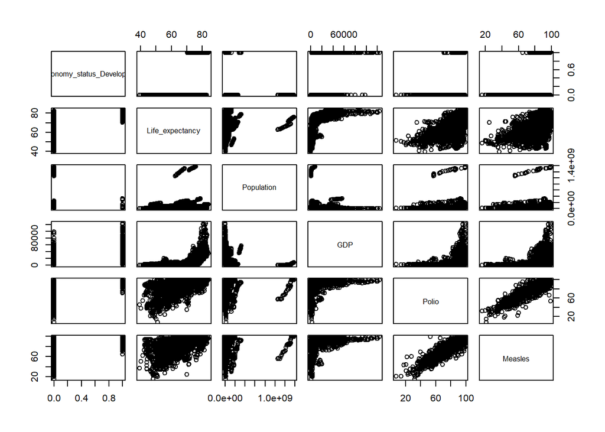

```r
pairs(numeric_data[,c(7:12)])
```

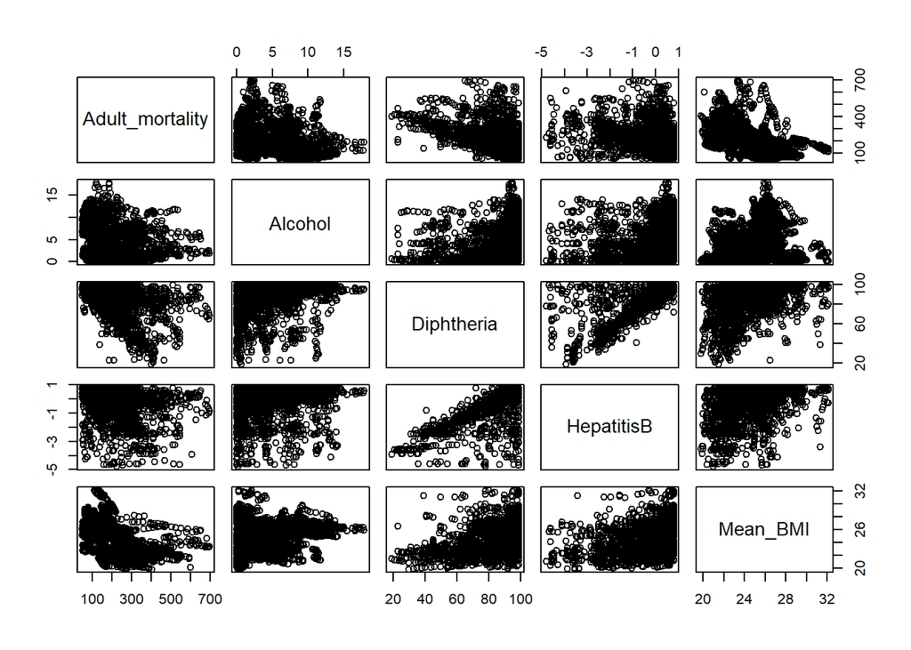

```r
pairs(numeric_data[,c(13:17)])
```

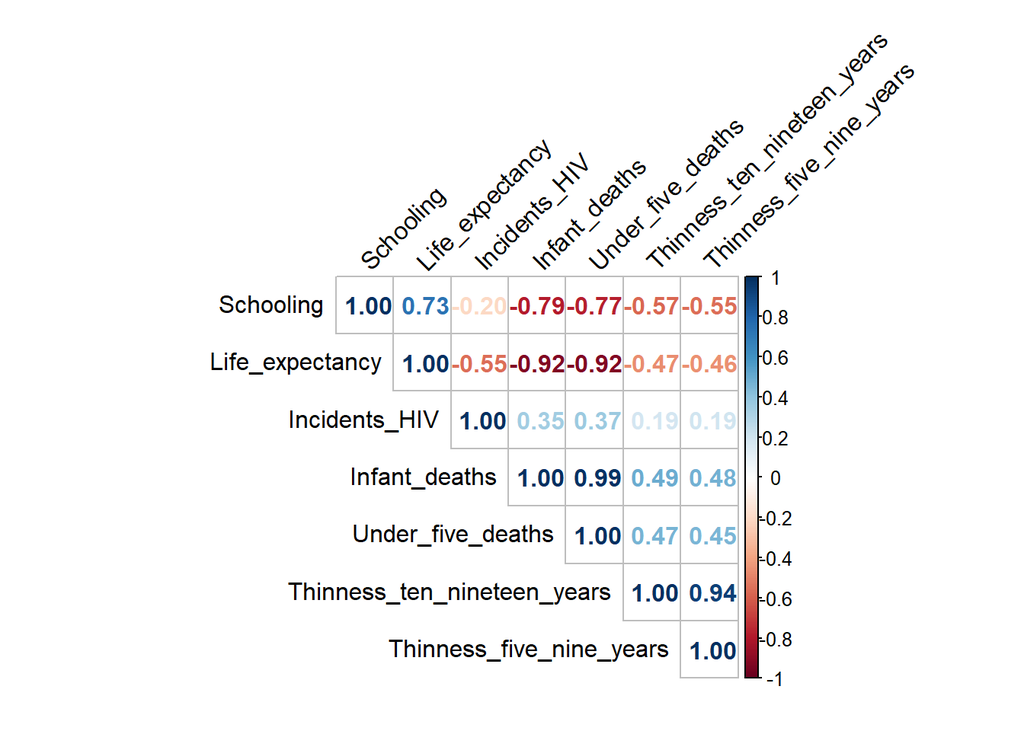

```r
# Have always Life expectancy in the corrplots because it is our response (use corrplot library)
# There is no meaning for columns Economy_status_Developed/Developing as they have values only 0 or 1
corrplot(cor(numeric_data[,c(1:6,8)]), type = "upper", order = "hclust", tl.col = "black",
         tl.srt = 45, method = "number", number.cex = 1, addCoef.col = "black")
```

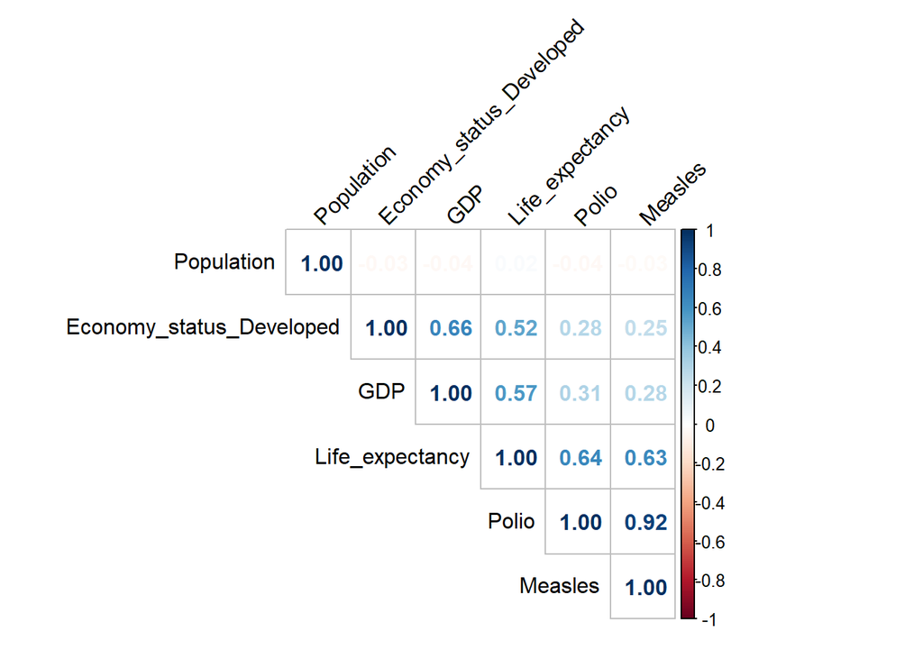

```r
corrplot(cor(numeric_data[,c(7:12)]), type = "upper", order = "hclust", tl.col = "black",
         tl.srt = 45, method = "number", number.cex = 1, addCoef.col = "black")
```

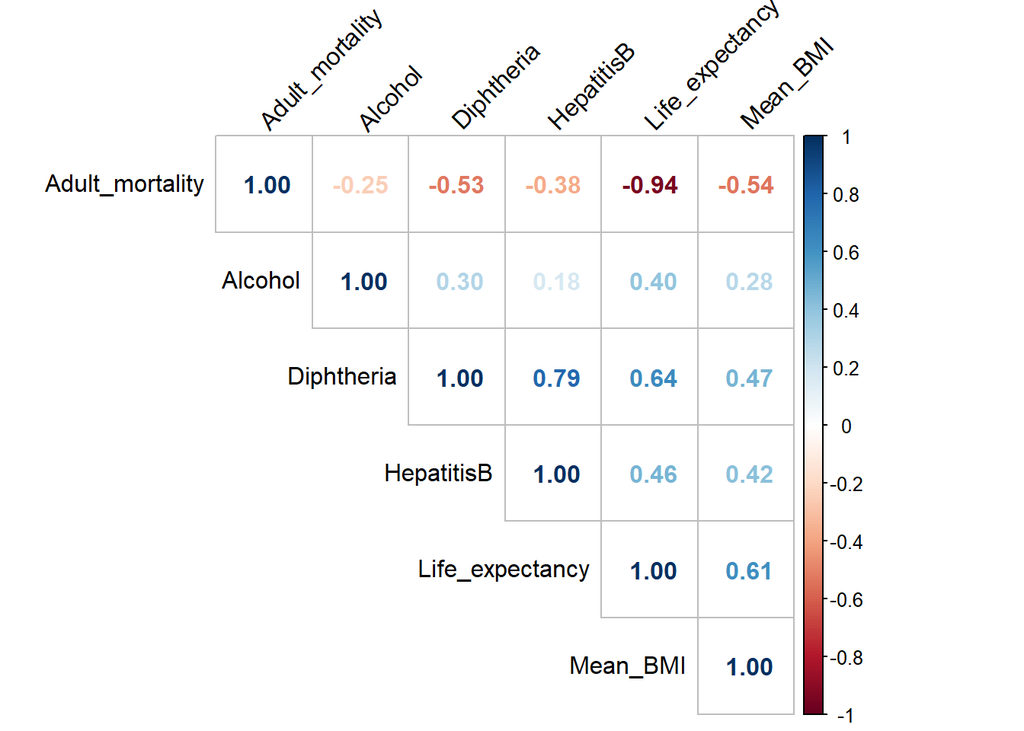

```r
corrplot(cor(numeric_data[,c(8, 13:17)]), type = "upper", order = "hclust", tl.col = "black",
         tl.srt = 45, method = "number", number.cex = 1, addCoef.col = "black")
```

Some pair plots

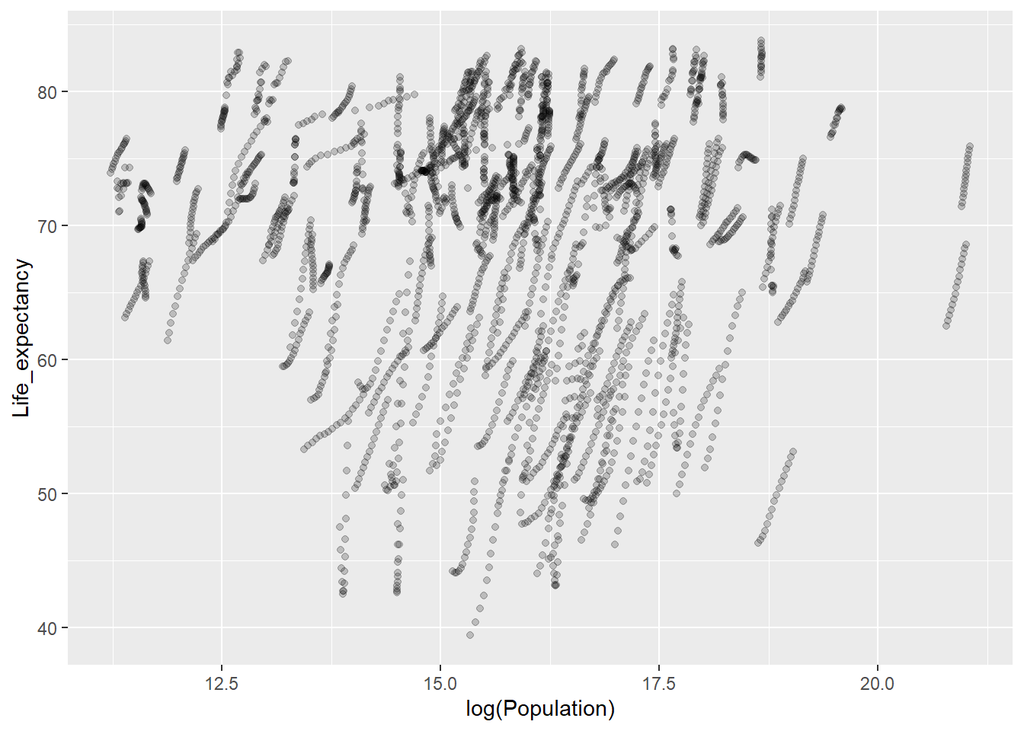

```r
# Check the relationship between the response and the predictors
ggplot(data = numeric_data) + geom_point(mapping = aes(x = log(Population), y = Life_expectancy),
                                        alpha = 1 / 5) # log Population
```

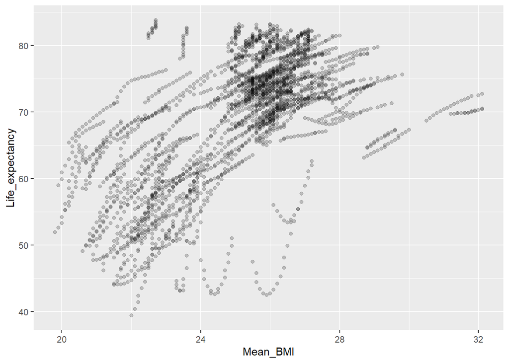

```r
ggplot(data = numeric_data) + geom_point(mapping = aes(x = Mean_BMI, y = Life_expectancy),
                                         alpha = 1 / 5)
```

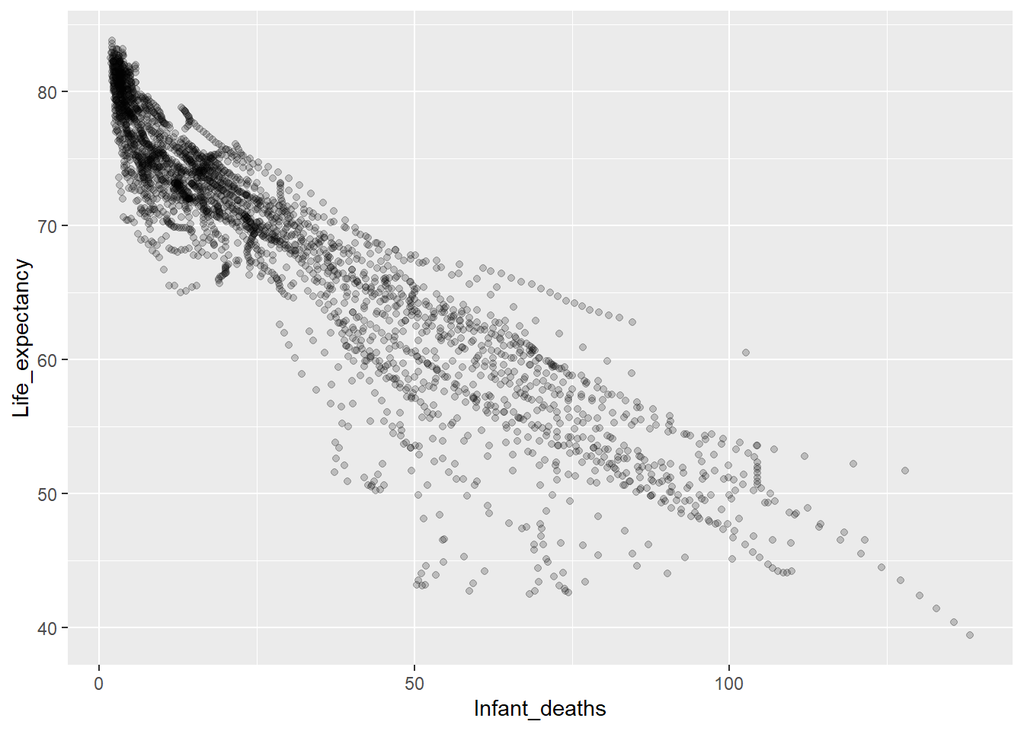

```r
ggplot(data = numeric_data) + geom_point(mapping = aes(x = Infant_deaths, y = Life_expectancy),
                                         alpha = 1 / 5)
```

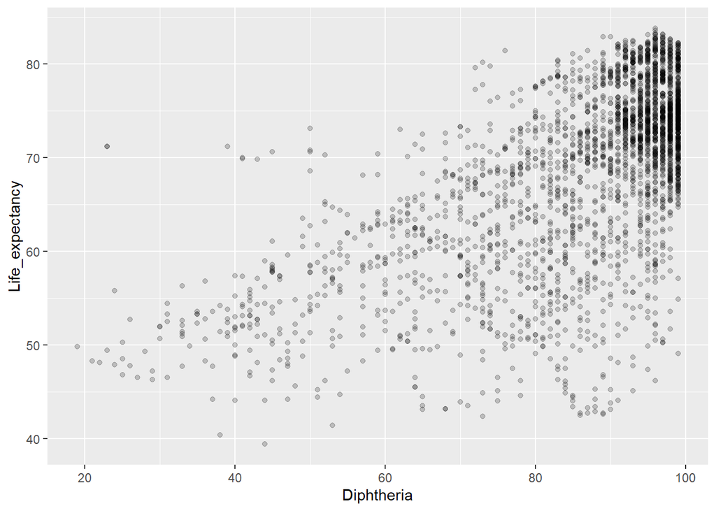

```r
ggplot(data = numeric_data) + geom_point(mapping = aes(x = Diphtheria, y = Life_expectancy),
                                         alpha = 1 / 5)
```

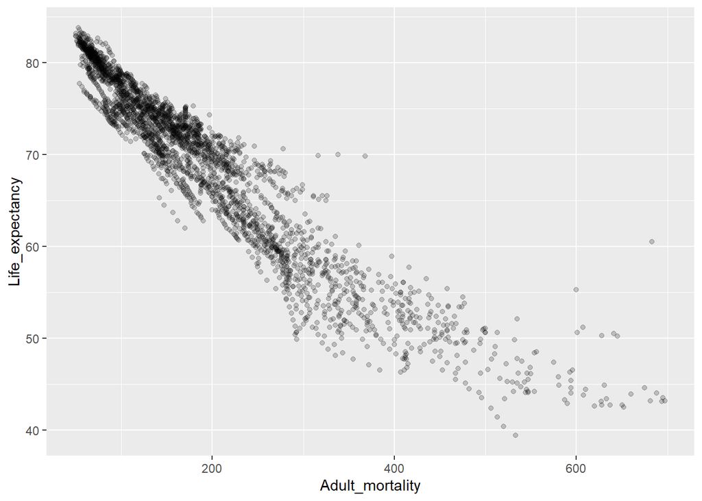

```r
ggplot(data = numeric_data) + geom_point(mapping = aes(x = Adult_mortality, y = Life_expectancy),
                                         alpha = 1 / 5)
```

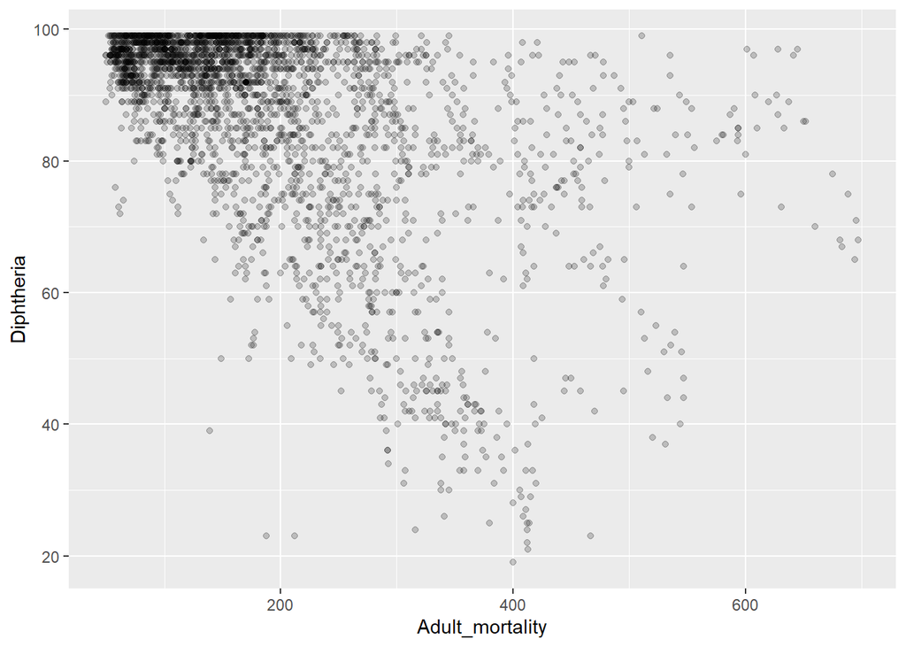

```r
# Check the relationship between the predictors
ggplot(data = numeric_data) + geom_point(mapping = aes(x = Adult_mortality, y = Diphtheria),
                                         alpha = 1 / 5)
```

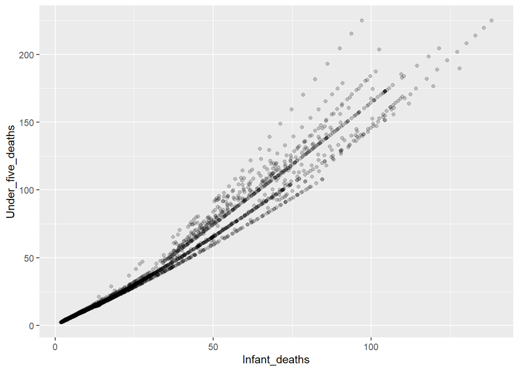

```r
ggplot(data = numeric_data) + geom_point(mapping = aes(x = Infant_deaths, y = Under_five_deaths),
                                         alpha = 1 / 5)
```

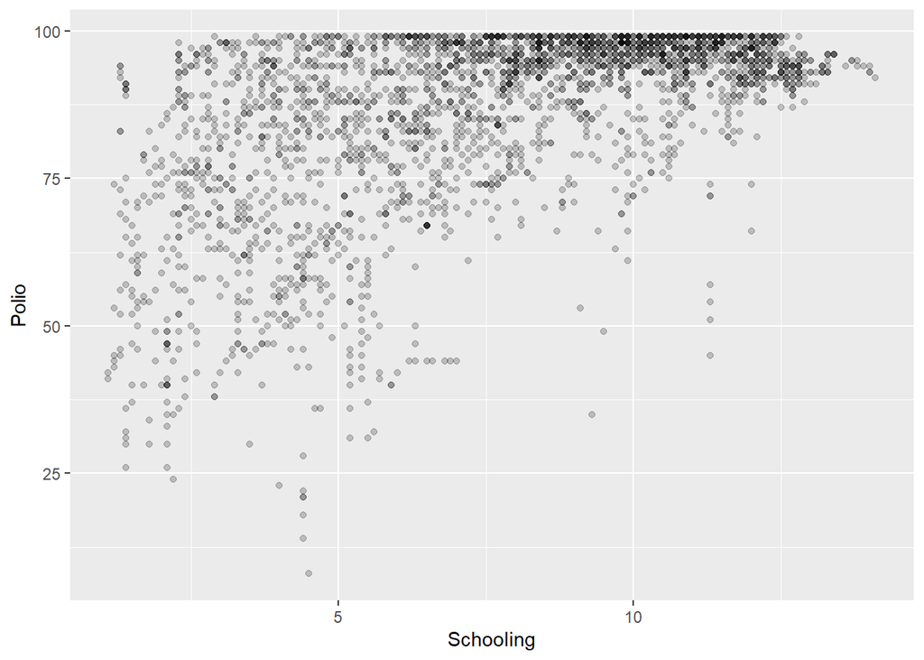

```r
ggplot(data = numeric_data) + geom_point(mapping = aes(x = Schooling, y = Polio),
                                         alpha = 1 / 5)
```

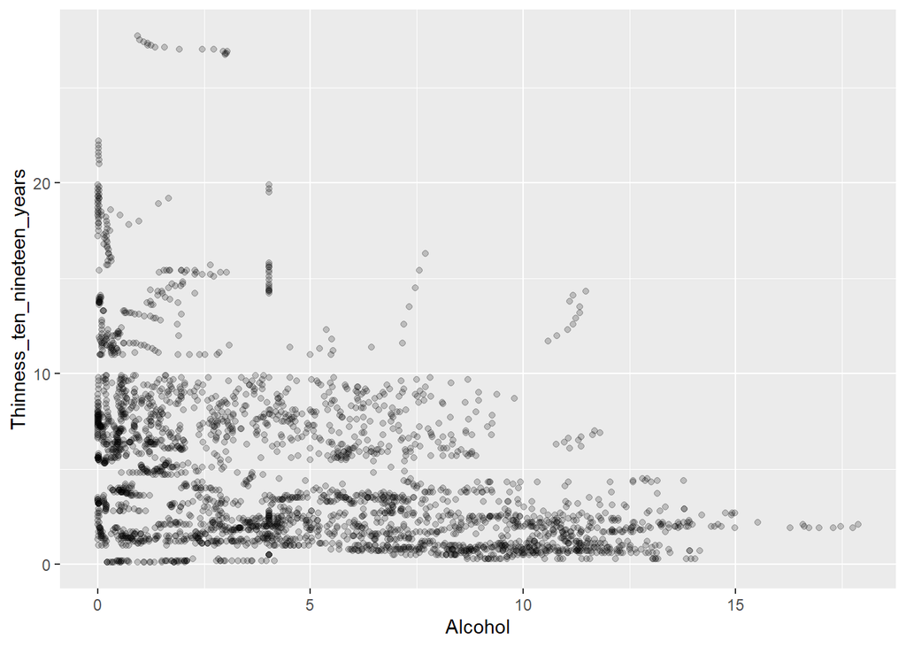

```r
ggplot(data = numeric_data) + geom_point(mapping = aes(x = Alcohol, y = Thinness_ten_nineteen_years),
                                         alpha = 1 / 5)
```

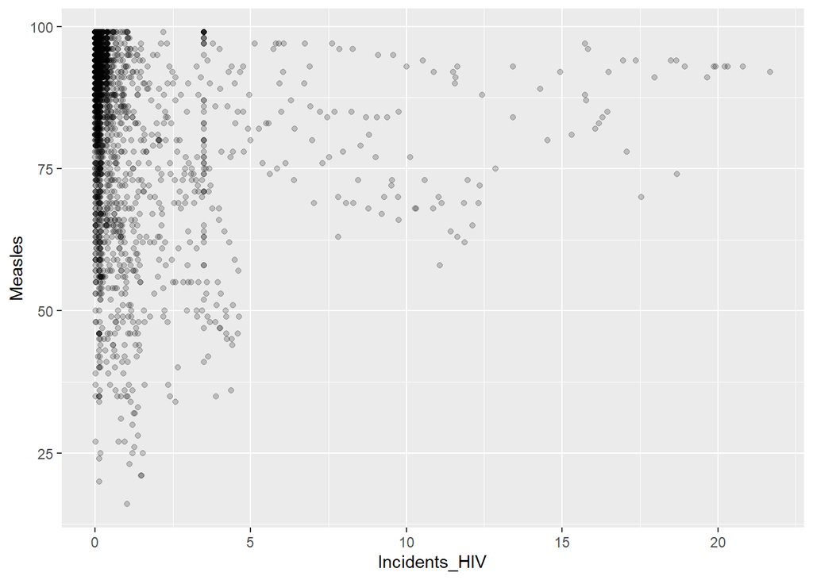

```r
ggplot(data = numeric_data) + geom_point(mapping = aes(x = Incidents_HIV, y = Measles),
                                         alpha = 1 / 5)
```

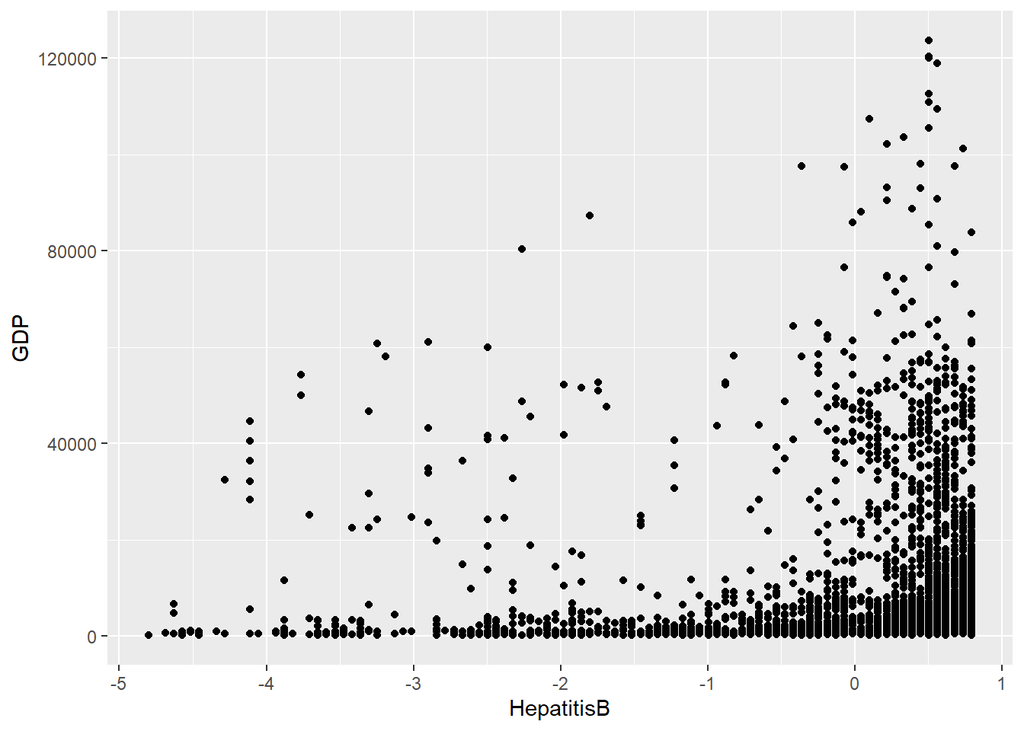

```r
ggplot(data = numeric_data) + geom_point(mapping = aes(x = HepatitisB, y = GDP))
```

We hope that the response variable has high correlations with the predictors

```r
# Correlations with Life expectancy
round(cor(numeric_data), 2)[8,]
```

```
##               Infant_deaths           Under_five_deaths
##                       -0.92                       -0.92
## Thinness_ten_nineteen_years    Thinness_five_nine_years
##                       -0.47                       -0.46
##                   Schooling               Incidents_HIV
##                        0.73                       -0.55
##    Economy_status_Developed             Life_expectancy
##                        0.52                        1.00
##                  Population                         GDP
##                        0.02                        0.57
##                       Polio                     Measles
##                        0.64                        0.63
##             Adult_mortality                     Alcohol
##                       -0.94                        0.40
##                  Diphtheria                  HepatitisB
##                        0.64                        0.46
##                    Mean_BMI
##                        0.61
```

Infant deaths, Under five deaths and Adult mortality are highly correlated with Life expectancy (the absolut value of the correlation between them is greater than 0.8). In general all the predictors are correlated with Life expectancy except Population. We are not going to remove Population right now. We expect that after feature selection it will not be among the important features and we want to confirm that later.

Among predictors we hope to have no correlation between them to avoid multicollinearity.

```r
# Correlations with Infant deaths
round(cor(numeric_data), 2)[1,]
```

```
##               Infant_deaths           Under_five_deaths
##                        1.00                        0.99
## Thinness_ten_nineteen_years    Thinness_five_nine_years
##                        0.49                        0.48
##                   Schooling               Incidents_HIV
##                       -0.79                        0.35
##    Economy_status_Developed             Life_expectancy
##                       -0.48                       -0.92
##                  Population                         GDP
##                        0.01                       -0.50
##                       Polio                     Measles
##                       -0.74                       -0.74
##             Adult_mortality                     Alcohol
##                        0.80                       -0.45
##                  Diphtheria                  HepatitisB
##                       -0.74                       -0.57
##                    Mean_BMI
##                       -0.67
```

Infant deaths is highly correlated with Under five deaths and Adult mortality. Also, Diphtheria, Polio and Measles has a high correlation with Infant deaths. After feature selection, we expect only one of these predictors to be among the important ones. As we are not sure which one is better we are not going to remove any of them right now. Unfortunately, infant deaths has correlations with all the features except population.

```r
# Correlations with Thinness 10-19 years
round(cor(numeric_data), 2)[3,]
```

```
##               Infant_deaths           Under_five_deaths
##                        0.49                        0.47
## Thinness_ten_nineteen_years    Thinness_five_nine_years
##                        1.00                        0.94
##                   Schooling               Incidents_HIV
##                       -0.57                        0.19
##    Economy_status_Developed             Life_expectancy
##                       -0.42                       -0.47
##                  Population                         GDP
##                        0.25                       -0.36
##                       Polio                     Measles
##                       -0.31                       -0.34
##             Adult_mortality                     Alcohol
##                        0.39                       -0.43
##                  Diphtheria                  HepatitisB
##                       -0.32                       -0.26
##                    Mean_BMI
##                       -0.58
```

We can see again that Thinness 10-19 years has a very high correlation with Thinness 5-9 years which is reasonable because of what they are. There is some correlation with Schooling, Mean BMI Infant and Under five deaths. Let’s see after feature selection which variables we should keep.

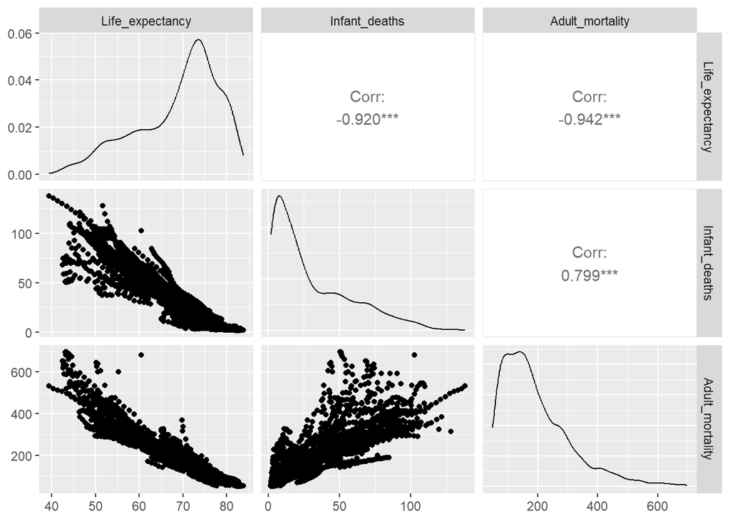

```r
# Create pairs plot, GGally library
ggpairs(dplyr::select(numeric_data, Life_expectancy, Infant_deaths, Adult_mortality))
```

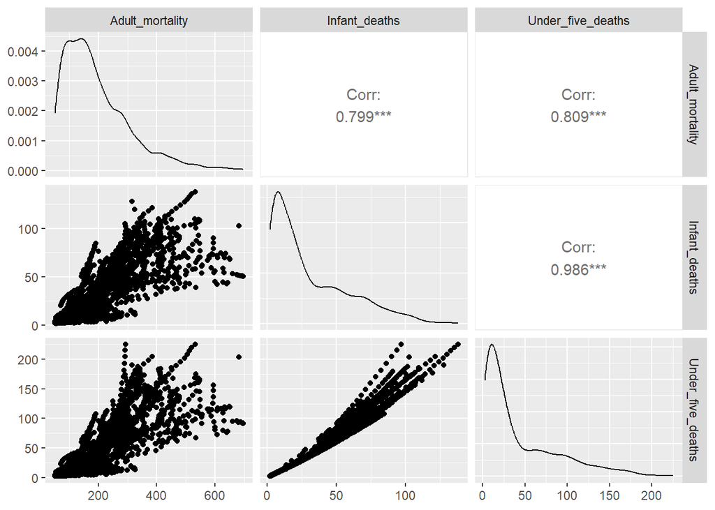

```r
ggpairs(dplyr::select(numeric_data, Adult_mortality, Infant_deaths, Under_five_deaths))
```

Check if the variables follow the same distribution with each other (alpha = 0.05, significance level)

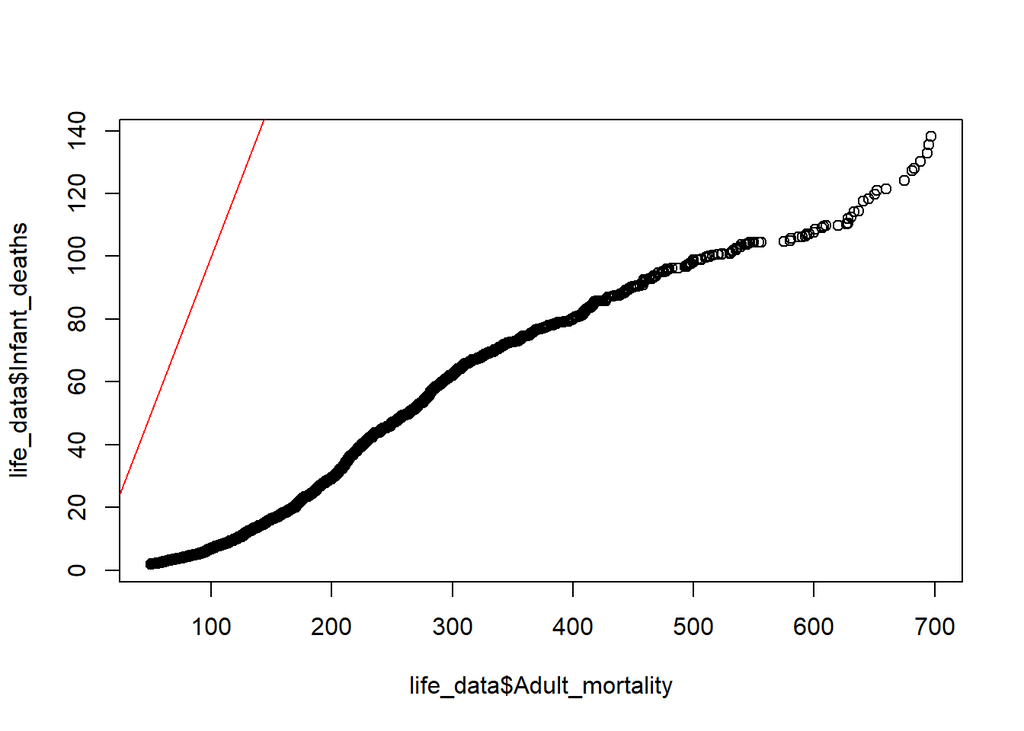

```r
qqplot(life_data$Adult_mortality, life_data$Infant_deaths)
abline(0,1, col = 'red')
```